# Does Breakfast Influence Academic Performance?

## Does breakfast influence academic performance?

This visual data story explores whether having breakfast may affect students’ energy levels and academic performance. The data was collected through repeated observational logging over time using a Google Form.

## Breakfast and academic performance

One possible factor influencing academic performance is whether students ate breakfast.

The bar chart below compares the **average academic performance rating** of students who had breakfast and students who did not.

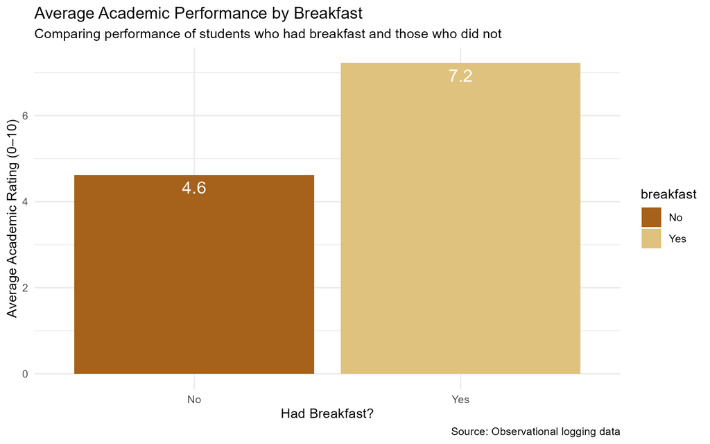

Bar chart comparing average academic performance ratings between students who had breakfast and students who did not.

Students who had breakfast generally reported **higher academic performance scores** than students who skipped breakfast. While this does not prove any correlation, it suggests breakfast may positively influence how students feel about their university performance.

## Energy level and academic performance

Feeling energized may influence how productive and academically successful students feel throughout the day.

The scatter plot below explores the relationship between **energy level** and **academic performance**, divided into 2 groups by color - whether student had breakfast or not.

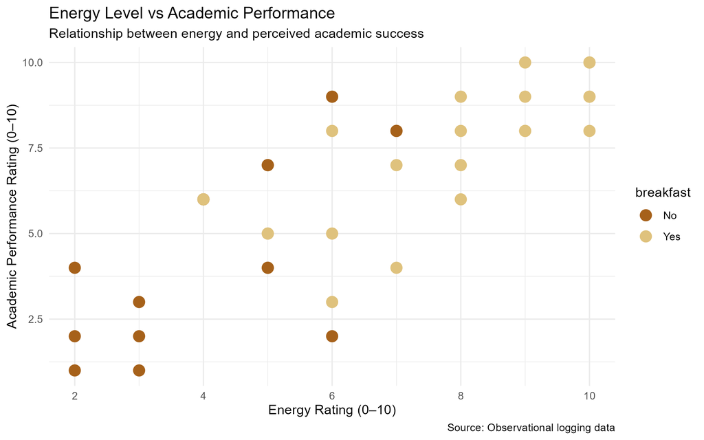

Scatterplot showing the relationship between energy rating and academic performance.

There appears to be a **positive relationship** between energy and academic performance. Higher energy ratings often correspond to higher academic ratings, suggesting energy may be an important contributor to productivity and study success.

## Energy levels over time

Energy levels can vary across different days and circumstances.

The plot below tracks **average energy levels over time** using time stamps collected from the observational logging data.

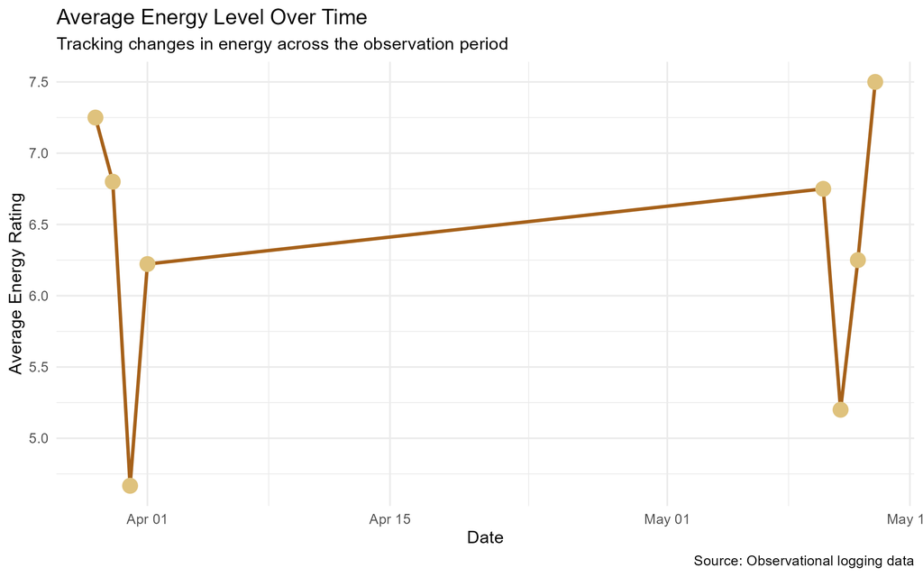

Line graph showing changes in average energy level across different dates.

Average energy levels changed throughout the observation period. This may reflect differences in breakfast habits, workload or factors like having test that day. Generally it gives us dates that we can explore and try to understand the cause behind over or under eating.

## Conclusion

Although this observational data cannot prove direct cause-and-effect relationships, it provides useful insight into how eating habits can shape university experiences.